# Eric Pastore

## CIS 397

## February 29, 2024

## Dr. Ladd

```python
%matplotlib inline
import numpy as np
import networkx as nx
import pandas as pd
import altair as alt
import nx_altair as nxa
```

# 1.

```python
HS = nx.read_weighted_edgelist("contact-high-school-proj-graph.txt")
print(HS)
```

```
Graph with 327 nodes and 5818 edges
```

```python
triangles = nx.triangles(HS)
```

```python
number_of_triangles = sum(triangles.values()) / 3
print(number_of_triangles)
```

```
34220.0
```

The anonymized high school interaction data attempts to determine the number of interactions high school students at a fictitious educational institute socially connect with one another on a daily basis. Specifically, this data seeks to find how many trios, or groups of 3 students, regularly associate with one another. These trios are represented as triangles in the network. By using a sum function, I was able to determine that this high school had 34,220 trios. In relation to the network, this is a small number. This is because the number of possible (hypothetical) trios is over 5.7 million.

# 2.

```python
clustering = nx.clustering(HS)
```

```python
nx.average_clustering(HS)
```

```
0.5035048191728446
```

```python
nx.set_node_attributes(HS, clustering, 'clustering_coefficient')
```

```python
pos = nx.spring_layout(HS)
```

```python
alt.data_transformers.disable_max_rows()
viz = nxa.draw_networkx(HS,
                        pos=pos,
                        node_color='clustering_coefficient',
                       )
```

```python
viz.interactive()
```

[interactive chart not shown]

```python
nodes = pd.DataFrame.from_dict(HS.nodes, orient='index')
nodes.reset_index(level=0,inplace=True)
nodes.sort_values("clustering_coefficient")
```

|  | index | clustering_coefficient |
| --- | --- | --- |
| 66 | 159 | 0.211041 |
| 284 | 60 | 0.227194 |
| 297 | 72 | 0.229665 |
| 182 | 263 | 0.247357 |
| 26 | 122 | 0.248634 |
| ... | ... | ... |
| 232 | 308 | 0.833333 |
| 213 | 291 | 0.866935 |
| 231 | 307 | 0.961538 |
| 42 | 137 | 0.977778 |
| 251 | 325 | 1.000000 |

327 rows × 2 columns

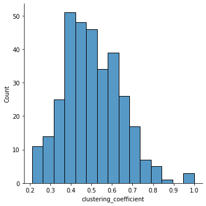

```python
import seaborn as sns
sns.displot(nodes, x="clustering_coefficient")
```

Diving deeper into the data, the average clustering coefficient seeks to determine the number of interactions that an individual student’s “neighbors” interact with one another. By using the average clustering coefficient function from the networkx library, I was able to determine that on average, a node will have a clustering coefficient over just over 0.5. In other words, this means that there is a 50/50 chance that student’s neighbors will interact with one another. These measures tell me that the network consists of a symmetrical balance between nodes and their edges that (when removed) disconnect the network and nodes and their edges that also (when removed) do not disconnect the network.